# Data Cleaning and EDA

Yuki

2022-06-05

## Load Libraries

```r
library(ggplot2)
library(dplyr)
library(scales)
library(tidyr)
```

## Load Dataset

```r
setwd("C:/Users/Acer/Dropbox/PC/Documents/Master of Data Science/WQD7004 Programming for Data Science/wqd7004-group-project/data")
df=read.csv(file="data.csv")
head(df)
```

```
##   stn_code      sampling_date          state  location agency
## 1      150 February - M021990 Andhra Pradesh Hyderabad   <NA>
## 2      151 February - M021990 Andhra Pradesh Hyderabad   <NA>
## 3      152 February - M021990 Andhra Pradesh Hyderabad   <NA>
## 4      150    March - M031990 Andhra Pradesh Hyderabad   <NA>
## 5      151    March - M031990 Andhra Pradesh Hyderabad   <NA>
## 6      152    March - M031990 Andhra Pradesh Hyderabad   <NA>
##                                 type so2  no2 rspm spm
## 1 Residential, Rural and other Areas 4.8 17.4   NA  NA
## 2                    Industrial Area 3.1  7.0   NA  NA
## 3 Residential, Rural and other Areas 6.2 28.5   NA  NA
## 4 Residential, Rural and other Areas 6.3 14.7   NA  NA
## 5                    Industrial Area 4.7  7.5   NA  NA
## 6 Residential, Rural and other Areas 6.4 25.7   NA  NA
##   location_monitoring_station pm2_5       date
## 1                        <NA>    NA 1990-02-01
## 2                        <NA>    NA 1990-02-01
## 3                        <NA>    NA 1990-02-01
## 4                        <NA>    NA 1990-03-01
## 5                        <NA>    NA 1990-03-01
## 6                        <NA>    NA 1990-03-01
```

## Explore Dataset

```r
str(df)
```

```
## 'data.frame':    435742 obs. of  13 variables:
##  $ stn_code                   : chr  "150" "151" "152" "150" ...
##  $ sampling_date              : chr  "February - M021990" "February - M021990" "February - M021990" "March - M031990" ...
##  $ state                      : chr  "Andhra Pradesh" "Andhra Pradesh" "Andhra Pradesh" "Andhra Pradesh" ...
##  $ location                   : chr  "Hyderabad" "Hyderabad" "Hyderabad" "Hyderabad" ...
##  $ agency                     : chr  NA NA NA NA ...
##  $ type                       : chr  "Residential, Rural and other Areas" "Industrial Area" "Residential, Rural and other Areas" "Residential, Rural and other Areas" ...
##  $ so2                        : num  4.8 3.1 6.2 6.3 4.7 6.4 5.4 4.7 4.2 4 ...
##  $ no2                        : num  17.4 7 28.5 14.7 7.5 25.7 17.1 8.7 23 8.9 ...
##  $ rspm                       : num  NA NA NA NA NA NA NA NA NA NA ...
##  $ spm                        : num  NA NA NA NA NA NA NA NA NA NA ...
##  $ location_monitoring_station: chr  NA NA NA NA ...
##  $ pm2_5                      : num  NA NA NA NA NA NA NA NA NA NA ...
##  $ date                       : chr  "1990-02-01" "1990-02-01" "1990-02-01" "1990-03-01" ...
```

There are 13 variables and 435742 row of observations in total.

```r
summary(df)
```

```
##    stn_code         sampling_date         state             location
##  Length:435742      Length:435742      Length:435742      Length:435742
##  Class :character   Class :character   Class :character   Class :character
##  Mode  :character   Mode  :character   Mode  :character   Mode  :character
##
##
##
##
##     agency              type                so2              no2
##  Length:435742      Length:435742      Min.   :  0.00   Min.   :  0.00
##  Class :character   Class :character   1st Qu.:  5.00   1st Qu.: 14.00
##  Mode  :character   Mode  :character   Median :  8.00   Median : 22.00
##                                        Mean   : 10.83   Mean   : 25.81
##                                        3rd Qu.: 13.70   3rd Qu.: 32.20
##                                        Max.   :909.00   Max.   :876.00
##                                        NA's   :34646    NA's   :16233
##       rspm             spm         location_monitoring_station     pm2_5
##  Min.   :   0.0   Min.   :   0.0   Length:435742               Min.   :  3.0
##  1st Qu.:  56.0   1st Qu.: 111.0   Class :character            1st Qu.: 24.0
##  Median :  90.0   Median : 187.0   Mode  :character            Median : 32.0
##  Mean   : 108.8   Mean   : 220.8                               Mean   : 40.8
##  3rd Qu.: 142.0   3rd Qu.: 296.0                               3rd Qu.: 46.0
##  Max.   :6307.0   Max.   :3380.0                               Max.   :504.0
##  NA's   :40222    NA's   :237387                               NA's   :426428
##      date
##  Length:435742
##  Class :character
##  Mode  :character
##
##
##
##
```

Stn_code, sampling_date, state, location, agency, type, location_monitoring_station and date is labelled as character variables.

so2,no2,rspm,spm and pm2_5 are numerical variables with missing values and maybe outliers because of abnormal large maximum value.

```r
for(i in 1:13){
  x=sum(is.na(df[i]))
  print(paste(names(df[i]),x))
}
```

```
## [1] "stn_code 144077"
## [1] "sampling_date 3"
## [1] "state 0"
## [1] "location 3"
## [1] "agency 149481"
## [1] "type 5393"
## [1] "so2 34646"
## [1] "no2 16233"
## [1] "rspm 40222"
## [1] "spm 237387"
## [1] "location_monitoring_station 27491"
## [1] "pm2_5 426428"
## [1] "date 7"
```

There are missing value except state variable.

## Drop Unnecessary Variables

Since “sampling_date” carry same meaning as “date”, we may drop it.

stn_code, agency and location_monitoring_station also seen carry same meaning with location and state, we may drop it too.

```r
df$sampling_date=NULL
df$stn_code=NULL
df$agency=NULL
df$location_monitoring_station=NULL
head(df)
```

```
##            state  location                               type so2  no2 rspm spm
## 1 Andhra Pradesh Hyderabad Residential, Rural and other Areas 4.8 17.4   NA  NA
## 2 Andhra Pradesh Hyderabad                    Industrial Area 3.1  7.0   NA  NA
## 3 Andhra Pradesh Hyderabad Residential, Rural and other Areas 6.2 28.5   NA  NA
## 4 Andhra Pradesh Hyderabad Residential, Rural and other Areas 6.3 14.7   NA  NA
## 5 Andhra Pradesh Hyderabad                    Industrial Area 4.7  7.5   NA  NA
## 6 Andhra Pradesh Hyderabad Residential, Rural and other Areas 6.4 25.7   NA  NA
##   pm2_5       date
## 1    NA 1990-02-01
## 2    NA 1990-02-01
## 3    NA 1990-02-01
## 4    NA 1990-03-01
## 5    NA 1990-03-01
## 6    NA 1990-03-01
```

# Exploratary Data Analysis - Univariate

Let’s observe the other variables one by one.

### 1. State

```r
plotdata <- df %>%
  count(state) %>%
  mutate(pct = n / sum(n),
         pctlabel = paste0(round(pct*100), "%"))
plotdata
```

```
##                          state     n          pct pctlabel
## 1  andaman-and-nicobar-islands     1 2.294936e-06       0%
## 2               Andhra Pradesh 26368 6.051287e-02       6%
## 3            Arunachal Pradesh    90 2.065442e-04       0%
## 4                        Assam 19361 4.443226e-02       4%
## 5                        Bihar  2275 5.220979e-03       1%
## 6                   Chandigarh  8520 1.955285e-02       2%
## 7                 Chhattisgarh  7831 1.797164e-02       2%
## 8         Dadra & Nagar Haveli   634 1.454989e-03       0%
## 9                  Daman & Diu   782 1.794640e-03       0%
## 10                       Delhi  8551 1.962400e-02       2%
## 11                         Goa  6206 1.424237e-02       1%
## 12                     Gujarat 21279 4.883394e-02       5%
## 13                     Haryana  3420 7.848681e-03       1%
## 14            Himachal Pradesh 22896 5.254485e-02       5%
```

[output cut: 23 more lines]

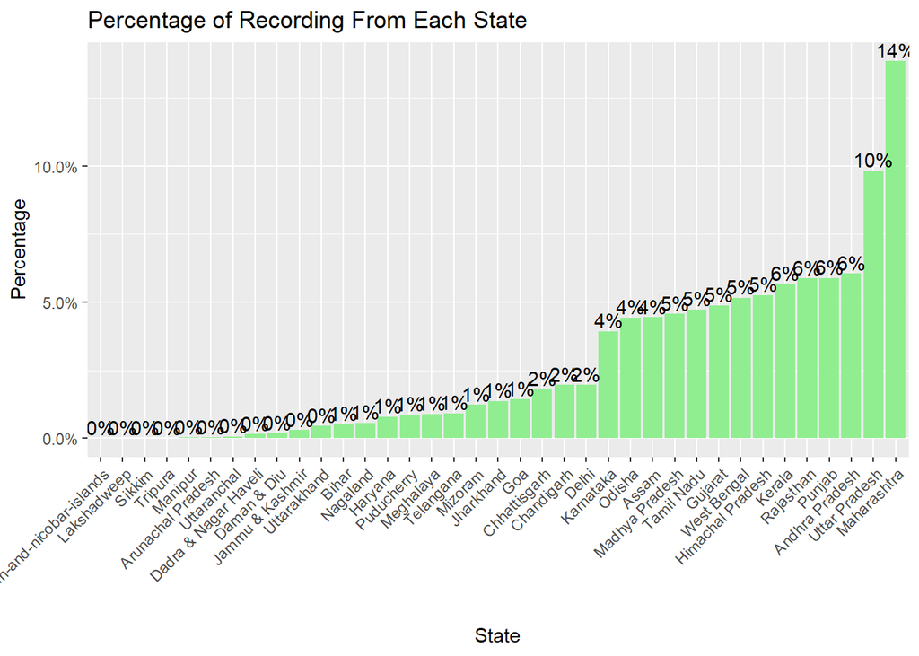

```r
p1<-ggplot(plotdata, aes(x=reorder(state, n),y=pct)) +
  geom_bar(stat = "identity", fill = "lightgreen") +
  geom_text(aes(label = pctlabel), vjust = -0.25) +
  theme(axis.text.x = element_text(angle = 45, hjust = 1))+
  scale_y_continuous(labels = percent) +
  labs(y = "Percentage",x="State", title = "Percentage of Recording From Each State")
p1
```

Maharashtra have most observations followed by Uttar Pradesh and others.

### 2.Location

```r
plotdata <- df %>%
  count(location) %>%
  mutate(pct = n / sum(n),
         pctlabel = paste0(round(pct*100), "%"))
plotdata
```

```
##                location    n          pct pctlabel
## 1                  Agra 7306 1.676680e-02       2%
## 2             Ahmedabad 6256 1.435712e-02       1%
## 3                Aizawl 3499 8.029981e-03       1%
## 4                 Akola 1048 2.405093e-03       0%
## 5             Alappuzha 1512 3.469943e-03       0%
## 6             Allahabad 1718 3.942700e-03       0%
## 7                 Alwar 3746 8.596830e-03       1%
## 8                 Amlai  119 2.730974e-04       0%
## 9                 Amona  299 6.861859e-04       0%
## 10             Amravati 2456 5.636363e-03       1%
## 11             Amritsar 1334 3.061445e-03       0%
## 12           Ananthapur  324 7.435593e-04       0%
## 13                Angul 2357 5.409164e-03       1%
## 14           Ankleshwar 1240 2.845721e-03       0%
```

[output cut: 291 more lines]

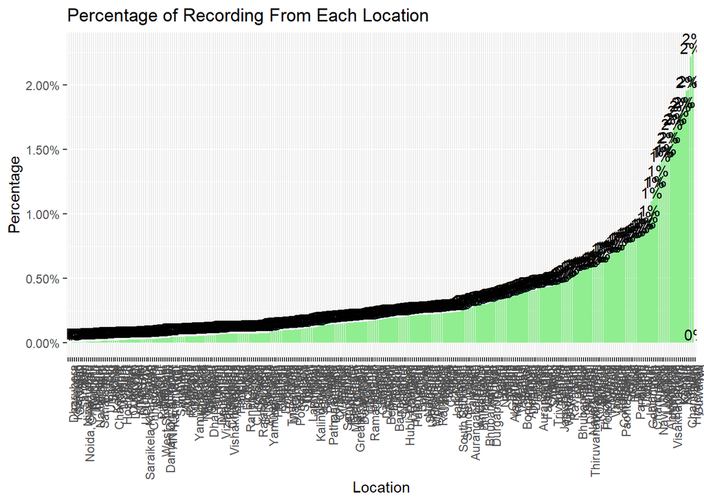

```r
p1<-ggplot(plotdata, aes(x = reorder(location, n),y=pct)) +
  geom_bar(stat = "identity", fill = "lightgreen") +
  geom_text(aes(label = pctlabel), vjust = -0.25) +
  theme(axis.text.x = element_text(angle = 90, hjust = 1))+
  scale_y_continuous(labels = percent) +
  labs(y = "Percentage", x = "Location", title = "Percentage of Recording From Each Location")
p1
```

There are 305 distinct value for Location variable. Guwahati is the largest class. There are 3 missing value, we may drop it later.

### 3. Type

```r
plotdata <- df %>%
  count(type) %>%
  mutate(pct = n / sum(n),
         pctlabel = paste0(round(pct*100), "%"))
plotdata
```

```
##                                  type      n          pct pctlabel
## 1                          Industrial    233 0.0005347201       0%
## 2                     Industrial Area  96091 0.2205226946      22%
## 3                    Industrial Areas  51747 0.1187560529      12%
## 4                         Residential    158 0.0003625999       0%
## 5              Residential and others  86791 0.1991797899      20%
## 6  Residential, Rural and other Areas 179014 0.4108256721      41%
## 7                               RIRUO   1304 0.0029925965       0%
## 8                           Sensitive    495 0.0011359933       0%
## 9                      Sensitive Area   8980 0.0206085252       2%
## 10                    Sensitive Areas   5536 0.0127047657       1%
## 11                               <NA>   5393 0.0123765898       1%
```

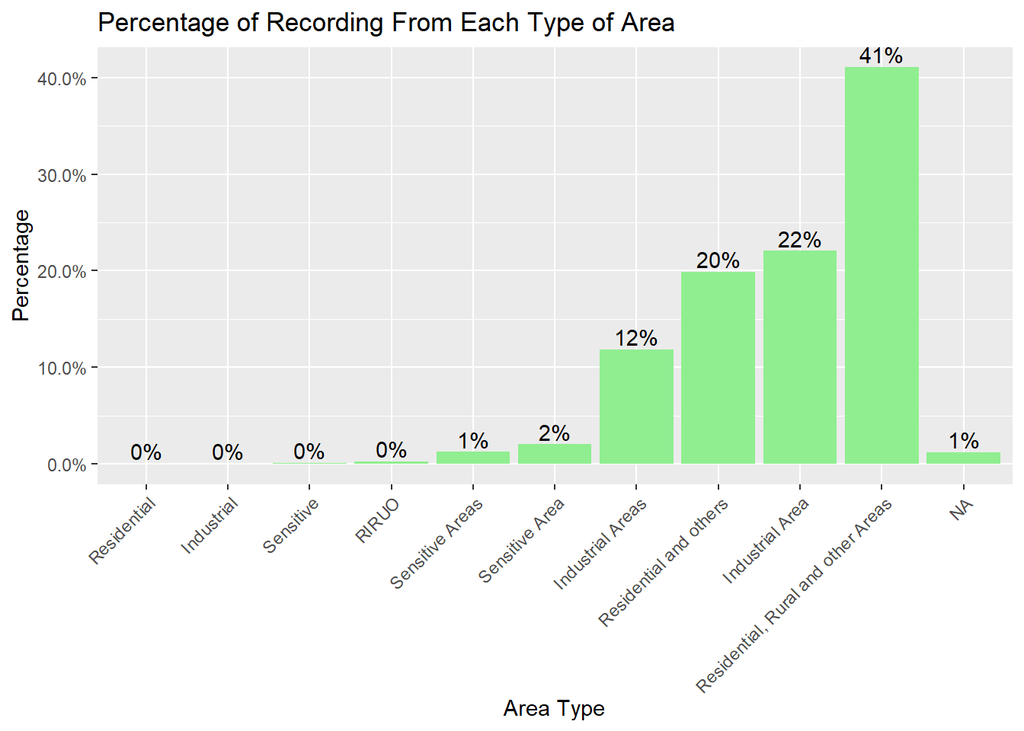

```r
p1<-ggplot(plotdata, aes(x = reorder(type, n), y=pct)) +
  geom_bar(stat = "identity", fill = "lightgreen") +
  geom_text(aes(label = pctlabel), vjust = -0.25) +
  theme(axis.text.x = element_text(angle = 45, hjust = 1))+
  scale_y_continuous(labels = percent) +
  labs(y = "Percentage", x="Area Type", title = "Percentage of Recording From Each Type of Area")
p1
```

We can group the data into “residual”, “industrial” and “others” class.

```r
df$type[df$type %in% "Residential, Rural and other Areas"] <- "Residential"
df$type[df$type %in% "Residential and others"] <- "Residential"
df$type[df$type %in% "Industrial Area"] <- "Industrial"
df$type[df$type %in% "Industrial Areas"] <- "Industrial"
df$type[df$type %in% "RIRUO"] <- "Others"
df$type[df$type %in% "Sensitive"] <- "Others"
df$type[df$type %in% "Sensitive Areas"] <- "Others"
df$type[df$type %in% "Sensitive Area"] <- "Others"
df$type[is.na(df$type)]= "Others"
```

```r
plotdata <- df %>%
  count(type) %>%
  mutate(pct = n / sum(n),
         pctlabel = paste0(round(pct*100), "%"))
plotdata
```

```
##          type      n        pct pctlabel
## 1  Industrial 148071 0.33981347      34%
## 2      Others  21708 0.04981847       5%
## 3 Residential 265963 0.61036806      61%
```

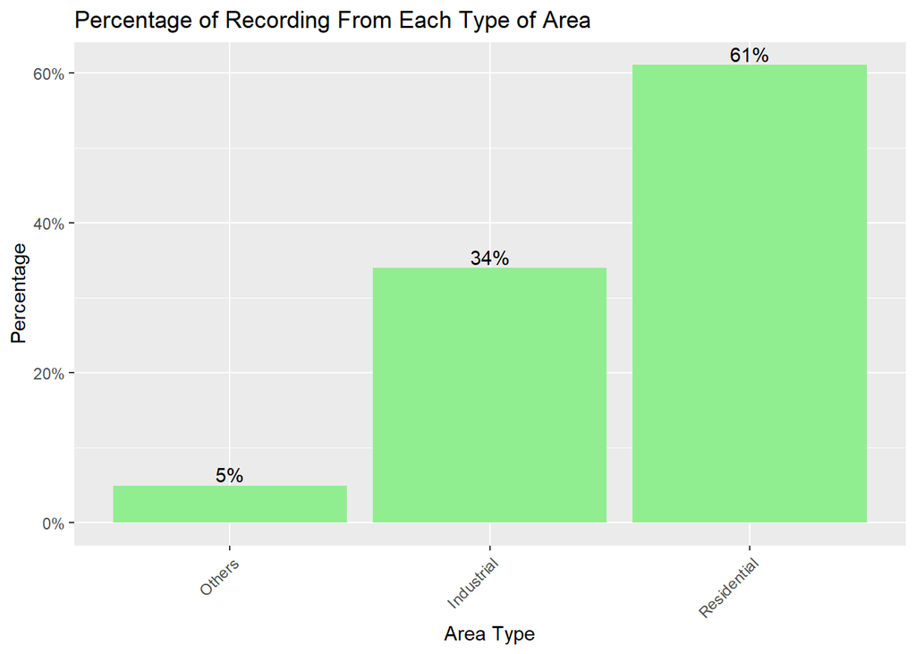

```r
p1<-ggplot(plotdata, aes(x = reorder(type, n), y=pct)) +
  geom_bar(stat = "identity", fill = "lightgreen") +
  geom_text(aes(label = pctlabel), vjust = -0.25) +
  theme(axis.text.x = element_text(angle = 45, hjust = 1))+
  scale_y_continuous(labels = percent) +
  labs(y = "Percentage", x="Area Type", title = "Percentage of Recording From Each Type of Area")
p1
```

Now there is only 3 groups in area type.

### 4. Sulfur dioxide (SO2)

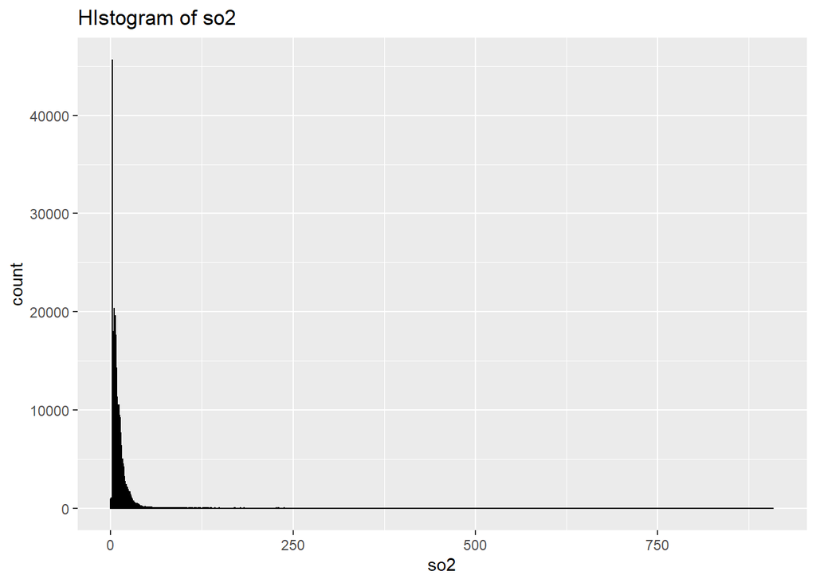

```r
p1<-ggplot(df, aes(x = so2)) +
  geom_histogram(binwidth=0.1, colour="black", fill = "lightgreen")+
  labs(title = "HIstogram of so2")
p1
```

There are 34646 rows of missing value in “so2”.

We can try focus on range(0~100) for drawing graph.

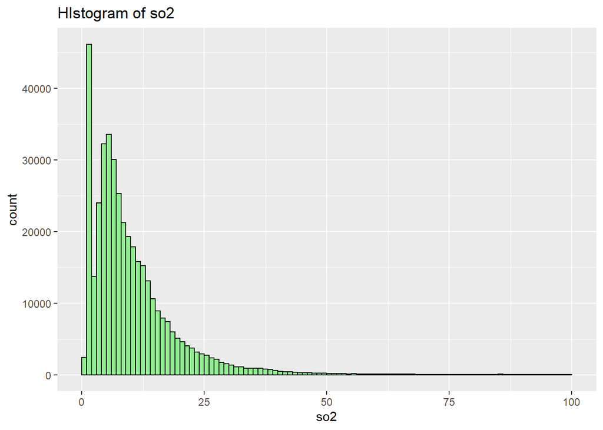

```r
p1<-ggplot(df, aes(x = so2)) +
  geom_histogram(binwidth=0.1, breaks= seq(0,100), colour="black", fill = "lightgreen")+
  labs(title = "HIstogram of so2")
p1
```

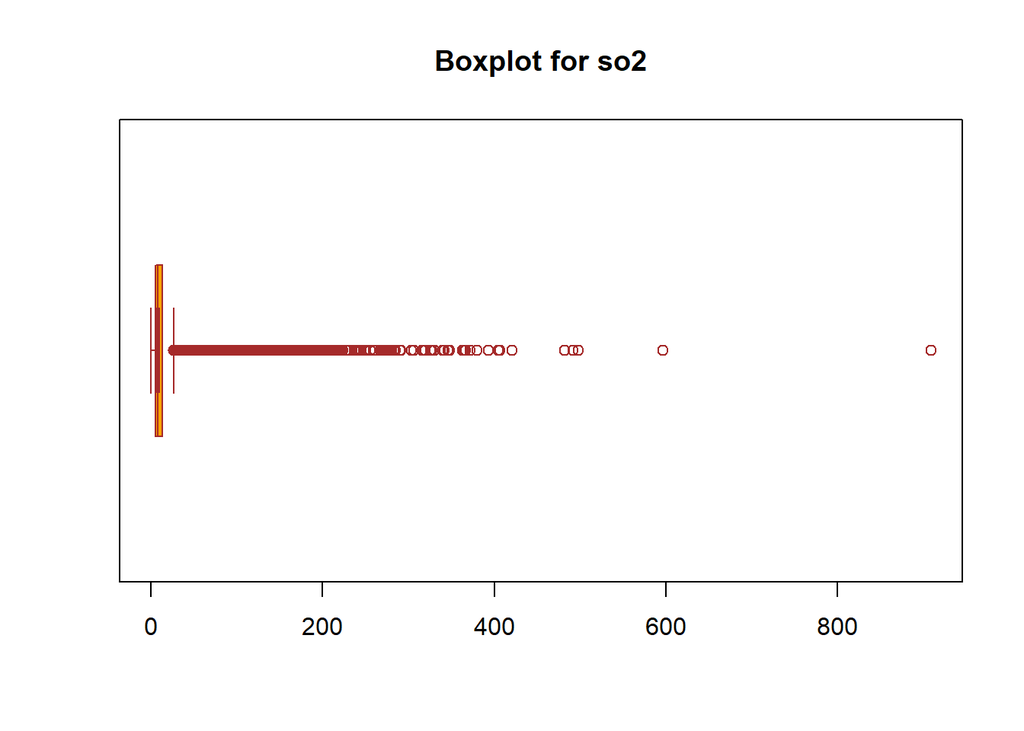

```r
boxplot(df$so2,
main = "Boxplot for so2",
col = "orange",
border = "brown",
horizontal = TRUE,
notch = TRUE
)
```

We can observe that the data is right skewed, data scattered around low value of so2 value.

There are outliers in the dataset, we will be cleaning it later.

### 5. Nitrogen dioxide (nO2)

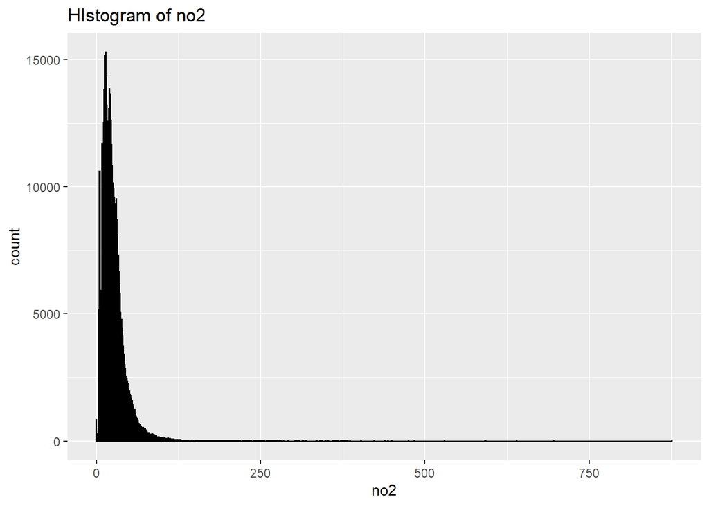

```r
p1<-ggplot(df, aes(x = no2)) +
  geom_histogram(binwidth=1, colour="black", fill = "lightgreen")+
  labs(title = "HIstogram of no2")
p1
```

There are 16233 rows of missing value in “no2”.

We can try focus on range(0~200) for drawing graph.

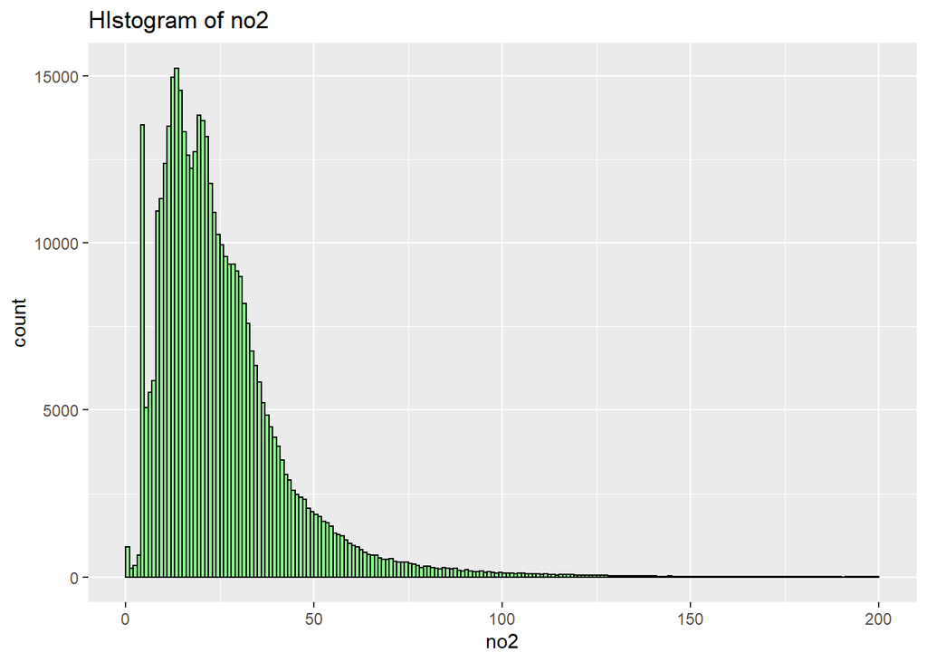

```r
p1<-ggplot(df, aes(x = no2)) +
  geom_histogram(binwidth=1, breaks= seq(0,200),colour="black", fill = "lightgreen")+
  labs(title = "HIstogram of no2")
p1
```

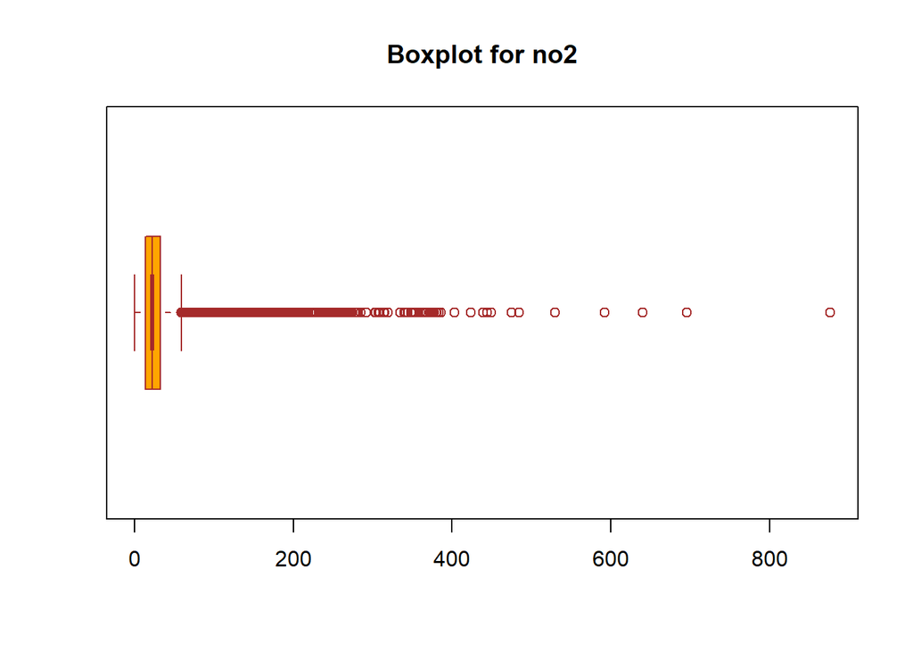

```r
boxplot(df$no2,
main = "Boxplot for no2",
col = "orange",
border = "brown",
horizontal = TRUE,
notch = TRUE
)
```

We can observe that the data is right skewed, data scattered around low value of no2 value.

There are outliers in the dataset, we will be cleaning it later.

### 6. Respirable Suspended Particulate Matter (rspm)

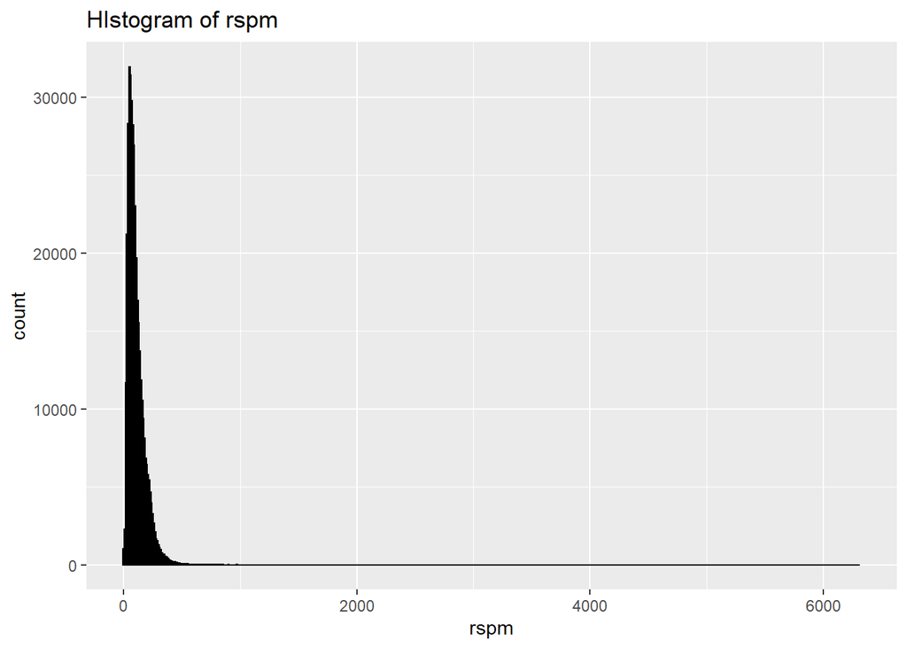

```r
p1<-ggplot(df, aes(x = rspm)) +
  geom_histogram(binwidth=10, colour="black", fill = "lightgreen")+
  labs(title = "HIstogram of rspm")
p1
```

There are 40222 rows of missing value in “rspm”.

We can try focus on range(0~1000) for drawing graph.

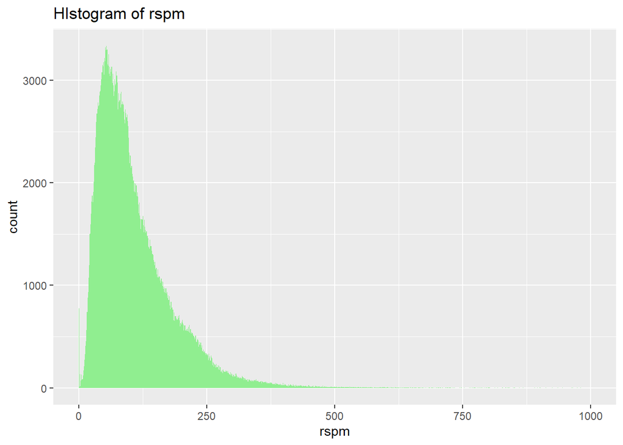

```r
p1<-ggplot(df, aes(x = rspm)) +
  geom_histogram(binwidth=100,  breaks= seq(0,1000), fill = "lightgreen")+
  labs(title = "HIstogram of rspm")
p1
```

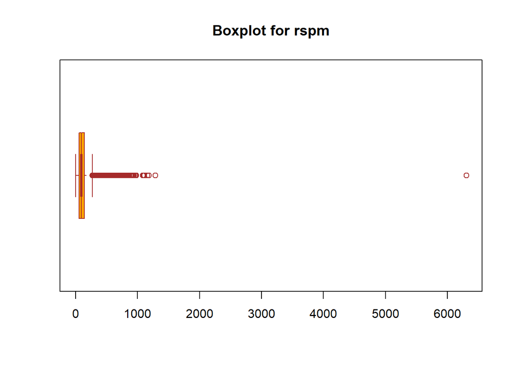

```r
boxplot(df$rspm,
main = "Boxplot for rspm",
col = "orange",
border = "brown",
horizontal = TRUE,
notch = TRUE
)
```

We can observe that the data is right skewed, data scattered around low value of rspm value.

There are outliers in the dataset, we will be cleaning it later.

### 7. Suspended particulate matter (spm)

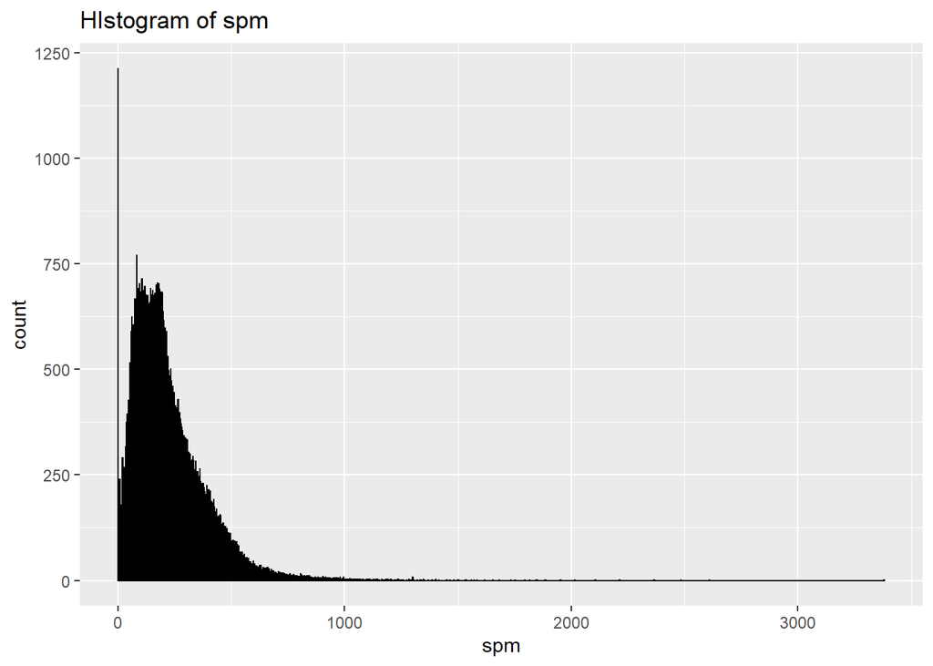

```r
p1<-ggplot(df, aes(x = spm)) +
  geom_histogram(binwidth=1, colour="black", fill = "lightgreen")+
  labs(title = "HIstogram of spm")
p1
```

There are 237387 rows of missing value in “spm”.

We can try focus on range(0~1000) for drawing graph.

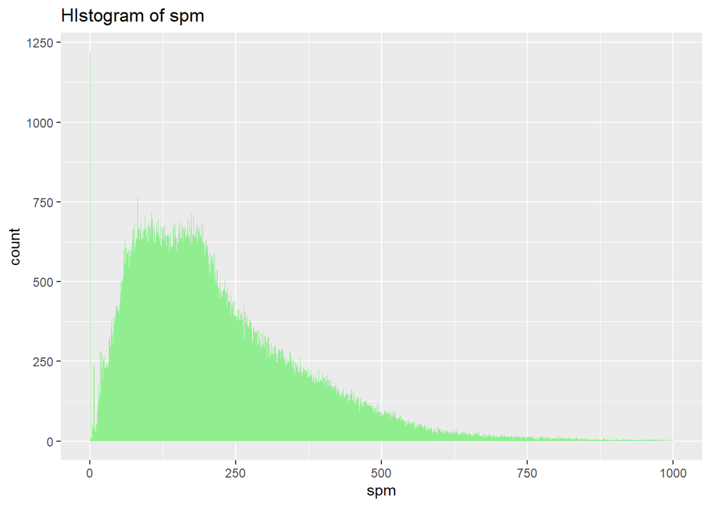

```r
p1<-ggplot(df, aes(x = spm)) +
  geom_histogram(binwidth=100, breaks= seq(0,1000) ,fill = "lightgreen")+
  labs(title = "HIstogram of spm")
p1
```

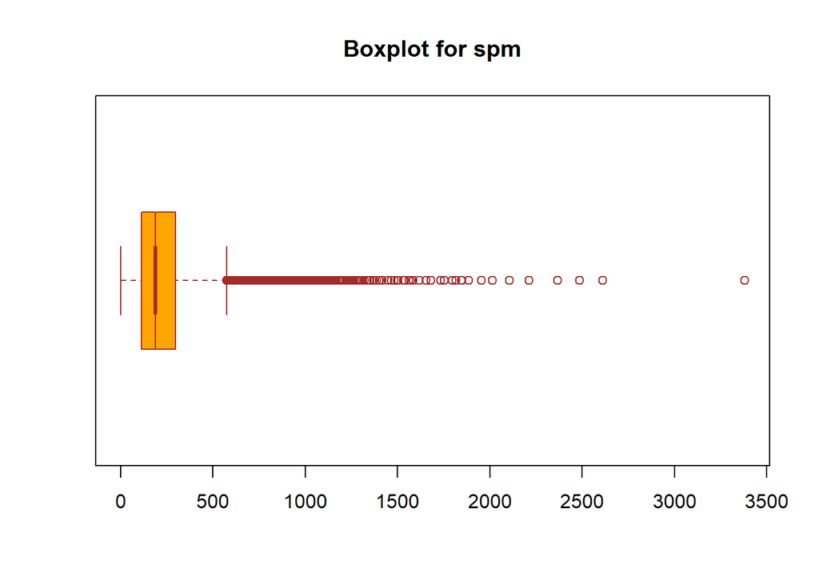

```r
boxplot(df$spm,
main = "Boxplot for spm",
col = "orange",
border = "brown",
horizontal = TRUE,
notch = TRUE
)
```

We can observe that the data is right skewed, data scattered around low value of spm value.

There are outliers in the dataset, we will be cleaning it later.

### 8. Fine particulate matter (pm2.5)

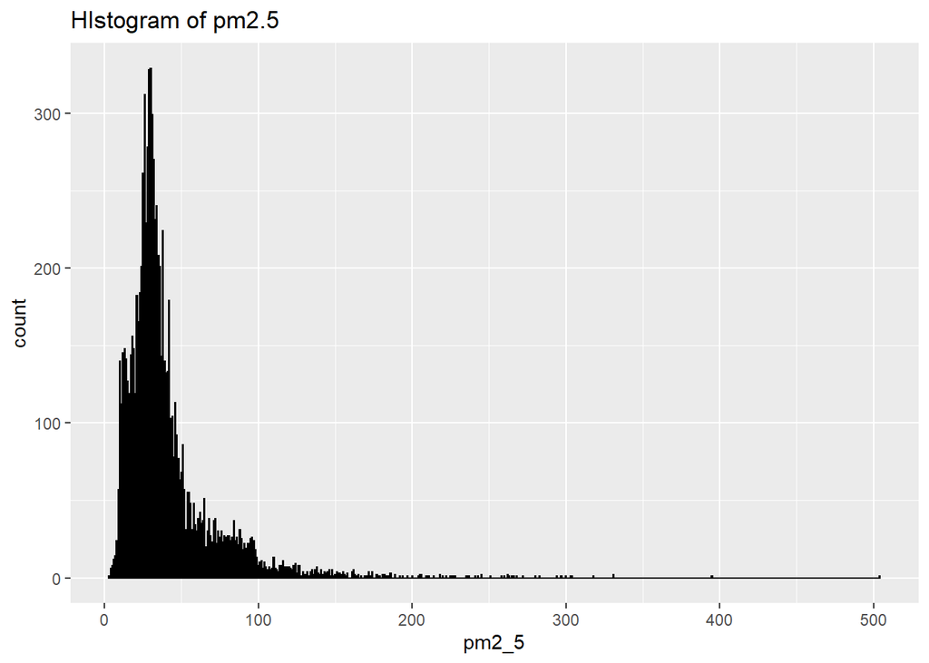

```r
##pm2_5
p1<-ggplot(df, aes(x = pm2_5)) +
  geom_histogram(binwidth=0.5, colour="black", fill = "lightgreen")+
  labs(title = "HIstogram of pm2.5")
p1
```

There are 426428 rows of missing value in “pm2_5”.

We can try focus on range(0~300) for drawing graph.

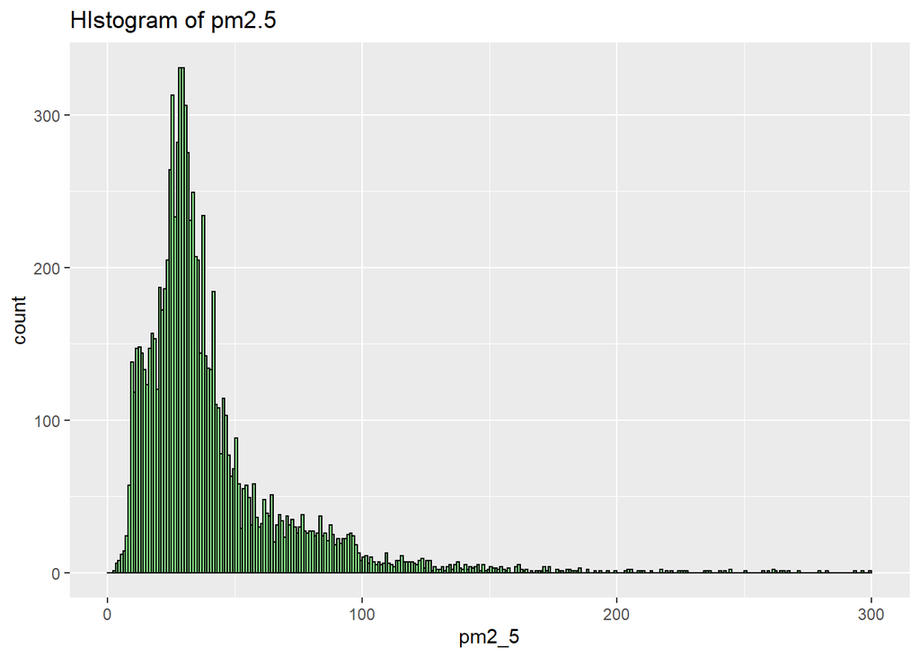

```r
p1<-ggplot(df, aes(x = pm2_5)) +
  geom_histogram(binwidth=0.5, breaks= seq(0,300), colour="black", fill = "lightgreen")+
  labs(title = "HIstogram of pm2.5")
p1
```

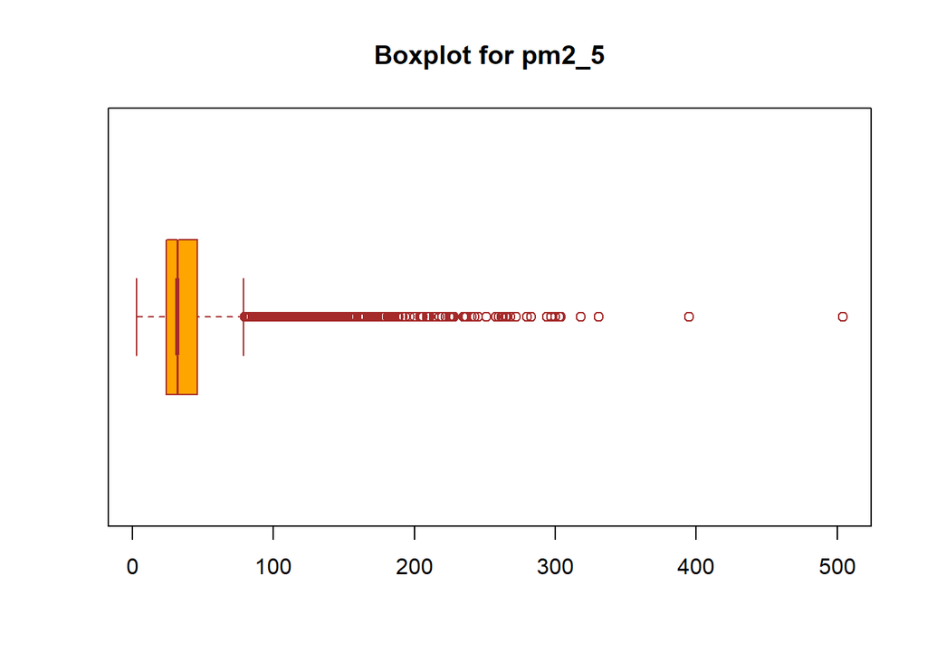

```r
boxplot(df$pm2_5,
main = "Boxplot for pm2_5",
col = "orange",
border = "brown",
horizontal = TRUE,
notch = TRUE
)
```

We can observe that the data is right skewed, data scattered around low value of pm2_5 value.

There are outliers in the dataset, we will be cleaning it later.

# Cleaning Outliers

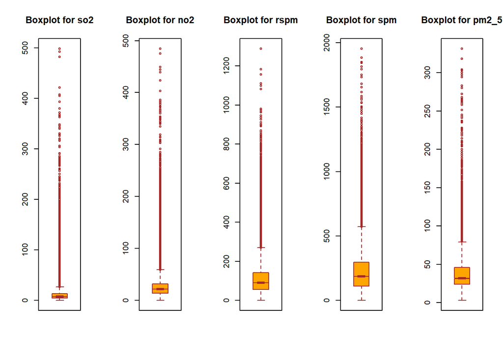

```r
df <- df %>% mutate(so2 = if_else(so2>500, mean(df$so2), df$so2))
df <- df %>% mutate(no2 = if_else(no2>500, mean(df$no2), df$no2))
df <- df %>% mutate(rspm = if_else(rspm>2000, mean(df$rspm), df$rspm))
df <- df %>% mutate(spm = if_else(spm>2000, mean(df$spm), df$spm))
df <- df %>% mutate(pm2_5 = if_else(pm2_5>350, mean(df$pm2_5), df$pm2_5))

par(mfrow=c(1,5))

boxplot(df$so2,
        main = "Boxplot for so2",
        col = "orange",
        border = "brown",
        notch = TRUE)

boxplot(df$no2,
        main = "Boxplot for no2",
        col = "orange",
        border = "brown",
        notch = TRUE)

boxplot(df$rspm,
        main = "Boxplot for rspm",
        col = "orange",
        border = "brown",
        notch = TRUE)

boxplot(df$spm,
        main = "Boxplot for spm",
        col = "orange",
        border = "brown",
        notch = TRUE)

boxplot(df$pm2_5,
        main = "Boxplot for pm2_5",
        col = "orange",
        border = "brown",
        notch = TRUE)
```

# Create Subset

Because we want to build two models,

1. time series regression for predicting pm2.5 for year 2014 and 2015.
2. clustering using all data. so, we first make a subset for first model and clean it.

## 1. Create Subset for Time Series Regression Model

```r
df_ts=subset(df, !is.na(pm2_5))
head(df_ts)
```

```
##                      state location       type so2 no2 rspm spm pm2_5
## 65037 Dadra & Nagar Haveli  Khadoli Industrial  18  31  104  NA    35
## 65038 Dadra & Nagar Haveli  Khadoli Industrial  14  26   94  NA    32
## 65039 Dadra & Nagar Haveli  Khadoli Industrial  16  28   99  NA    35
## 65040 Dadra & Nagar Haveli  Khadoli Industrial  13  23   82  NA    24
## 65041 Dadra & Nagar Haveli  Khadoli Industrial  14  29   93  NA    32
## 65042 Dadra & Nagar Haveli  Khadoli Industrial  13  25   77  NA    22
##             date
## 65037 2015-08-06
## 65038 2015-08-10
## 65039 2015-08-13
## 65040 2015-08-20
## 65041 2015-08-24
## 65042 2015-08-26
```

```r
str(df_ts)
```

```
## 'data.frame':    9312 obs. of  9 variables:
##  $ state   : chr  "Dadra & Nagar Haveli" "Dadra & Nagar Haveli" "Dadra & Nagar Haveli" "Dadra & Nagar Haveli" ...
##  $ location: chr  "Khadoli" "Khadoli" "Khadoli" "Khadoli" ...
##  $ type    : chr  "Industrial" "Industrial" "Industrial" "Industrial" ...
##  $ so2     : num  18 14 16 13 14 13 12 15 14 16 ...
##  $ no2     : num  31 26 28 23 29 25 21 26 25 26 ...
##  $ rspm    : num  104 94 99 82 93 77 81 90 89 100 ...
##  $ spm     : num  NA NA NA NA NA NA NA NA NA NA ...
##  $ pm2_5   : num  35 32 35 24 32 22 27 29 27 34 ...
##  $ date    : chr  "2015-08-06" "2015-08-10" "2015-08-13" "2015-08-20" ...
```

### Cleaning Missing Values

```r
for(i in 1:9){
  x=sum(is.na(df_ts[i]))
  print(paste(names(df_ts[i]),x))}
```

```
## [1] "state 0"
## [1] "location 0"
## [1] "type 0"
## [1] "so2 119"
## [1] "no2 96"
## [1] "rspm 60"
## [1] "spm 9312"
## [1] "pm2_5 0"
## [1] "date 0"
```

so2,no2,rspm have missing values. spm is blank.

```r
df_ts$so2[is.na(df_ts$so2)]= mean(df_ts$so2, na.rm = TRUE)
df_ts$no2[is.na(df_ts$no2)]= mean(df_ts$no2, na.rm = TRUE)
df_ts$rspm[is.na(df_ts$rspm)]= mean(df_ts$rspm, na.rm = TRUE)
df_ts$spm=NULL

for(i in 1:8){
  x=sum(is.na(df_ts[i]))
  print(paste(names(df_ts[i]),x))}
```

```
## [1] "state 0"
## [1] "location 0"
## [1] "type 0"
## [1] "so2 0"
## [1] "no2 0"
## [1] "rspm 0"
## [1] "pm2_5 0"
## [1] "date 0"
```

There is no missing value now and we can export this subset out for visualization and modelling of time series regression.

### Rearrange According To Date

```r
df_ts=df_ts[(order(df_ts$date,decreasing=FALSE)),]
```

```r
head(df_ts)
```

```
##                 state   location        type  so2  no2 rspm pm2_5       date
## 193521 Madhya Pradesh     Bhopal Residential  2.0 18.0  198    81 2014-01-01
## 284916         Odisha    Cuttack Residential  2.0 37.0  151    95 2014-01-01
## 365619      Telangana Sangareddy  Industrial  1.8 66.3   99    54 2014-01-01
## 193352 Madhya Pradesh     Bhopal  Industrial  2.0 21.0  215    96 2014-01-02
## 284925         Odisha    Cuttack Residential  2.0 34.0  142    82 2014-01-02
## 365650      Telangana Sangareddy  Industrial 12.4 86.3  149    78 2014-01-02
```

```r
str(df_ts)
```

```
## 'data.frame':    9312 obs. of  8 variables:
##  $ state   : chr  "Madhya Pradesh" "Odisha" "Telangana" "Madhya Pradesh" ...
##  $ location: chr  "Bhopal" "Cuttack" "Sangareddy" "Bhopal" ...
##  $ type    : chr  "Residential" "Residential" "Industrial" "Industrial" ...
##  $ so2     : num  2 2 1.8 2 2 ...
##  $ no2     : num  18 37 66.3 21 34 86.3 23 29 38.4 23 ...
##  $ rspm    : num  198 151 99 215 142 149 155 96 51 88 ...
##  $ pm2_5   : num  81 95 54 96 82 78 52 60 24 24 ...
##  $ date    : chr  "2014-01-01" "2014-01-01" "2014-01-01" "2014-01-02" ...
```

### Export Subset 1

```r
#write.csv(df_ts,"data_ts.csv", row.names=FALSE)
```

## 2. Create Subset for clustering Model

```r
df_c=df
df_c$pm2_5=NULL
df_c$date=NULL
head(df_c)
```

```
##            state  location        type so2  no2 rspm spm
## 1 Andhra Pradesh Hyderabad Residential 4.8 17.4   NA  NA
## 2 Andhra Pradesh Hyderabad  Industrial 3.1  7.0   NA  NA
## 3 Andhra Pradesh Hyderabad Residential 6.2 28.5   NA  NA
## 4 Andhra Pradesh Hyderabad Residential 6.3 14.7   NA  NA
## 5 Andhra Pradesh Hyderabad  Industrial 4.7  7.5   NA  NA
## 6 Andhra Pradesh Hyderabad Residential 6.4 25.7   NA  NA
```

We dropped pm2.5 because it is the target variable and it is only avaliable for last 2 year. We dropped date because clustering model no need time variable.

### Cleaning Missing Values

```r
for(i in 1:7){
  x=sum(is.na(df_c[i]))
  print(paste(names(df_c[i]),x))}
```

```
## [1] "state 0"
## [1] "location 3"
## [1] "type 0"
## [1] "so2 34648"
## [1] "no2 16239"
## [1] "rspm 40223"
## [1] "spm 237394"
```

location, so2,no2,rspm and spm have missing values

```r
df_c$type[is.na(df$so2)]= mean(df_c$so2, na.rm = TRUE)
df_c$type[is.na(df$no2)]= mean(df_c$no2, na.rm = TRUE)
df_c$type[is.na(df$rspm)]= mean(df_c$rspm, na.rm = TRUE)
df_c$type[is.na(df$spm)]= mean(df_c$spm, na.rm = TRUE)
df_c <- df_c %>% na.omit(df_c)

for(i in 1:7){
  x=sum(is.na(df_c[i]))
  print(paste(names(df_c[i]),x))}
```

```
## [1] "state 0"
## [1] "location 0"
## [1] "type 0"
## [1] "so2 0"
## [1] "no2 0"
## [1] "rspm 0"
## [1] "spm 0"
```

```r
head(df_c)
```

```
##               state  location       type  so2   no2  rspm   spm
## 1037 Andhra Pradesh Hyderabad Industrial 12.9  55.8 143.7 370.7
## 1038 Andhra Pradesh Hyderabad Industrial 10.4  48.9 124.7 285.7
## 1039 Andhra Pradesh Hyderabad Industrial  7.6  50.1  88.0 221.3
## 1040 Andhra Pradesh Hyderabad Industrial  7.3  48.5  82.7 186.7
## 1041 Andhra Pradesh Hyderabad Industrial  6.8 110.3 122.3 270.7
## 1042 Andhra Pradesh Hyderabad Industrial  6.9 134.1 101.7 235.0
```

```r
str(df_c)
```

```
## 'data.frame':    141928 obs. of  7 variables:
##  $ state   : chr  "Andhra Pradesh" "Andhra Pradesh" "Andhra Pradesh" "Andhra Pradesh" ...
##  $ location: chr  "Hyderabad" "Hyderabad" "Hyderabad" "Hyderabad" ...
##  $ type    : chr  "Industrial" "Industrial" "Industrial" "Industrial" ...
##  $ so2     : num  12.9 10.4 7.6 7.3 6.8 6.9 6.2 6.3 6.1 5.2 ...
##  $ no2     : num  55.8 48.9 50.1 48.5 110.3 ...
##  $ rspm    : num  143.7 124.7 88 82.7 122.3 ...
##  $ spm     : num  371 286 221 187 271 ...
##  - attr(*, "na.action")= 'omit' Named int [1:293814] 1 2 3 4 5 6 7 8 9 10 ...
##   ..- attr(*, "names")= chr [1:293814] "1" "2" "3" "4" ...
```

### Export Subset 2

```r
#write.csv(df_c,"data_c.csv", row.names=FALSE)
```

### Exploratory Data Analysis - Multivariate

### 1. correlation

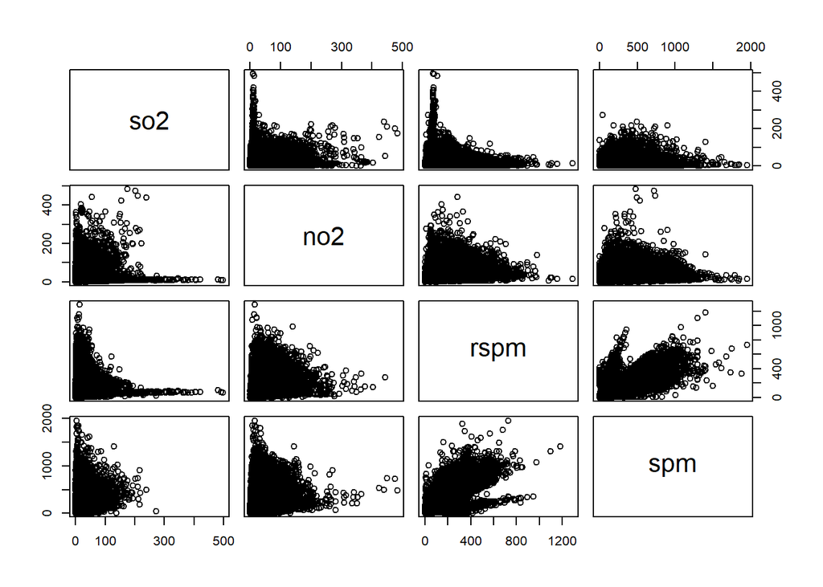

```r
pairs(~ so2 + no2 + rspm + spm, data=df)
```

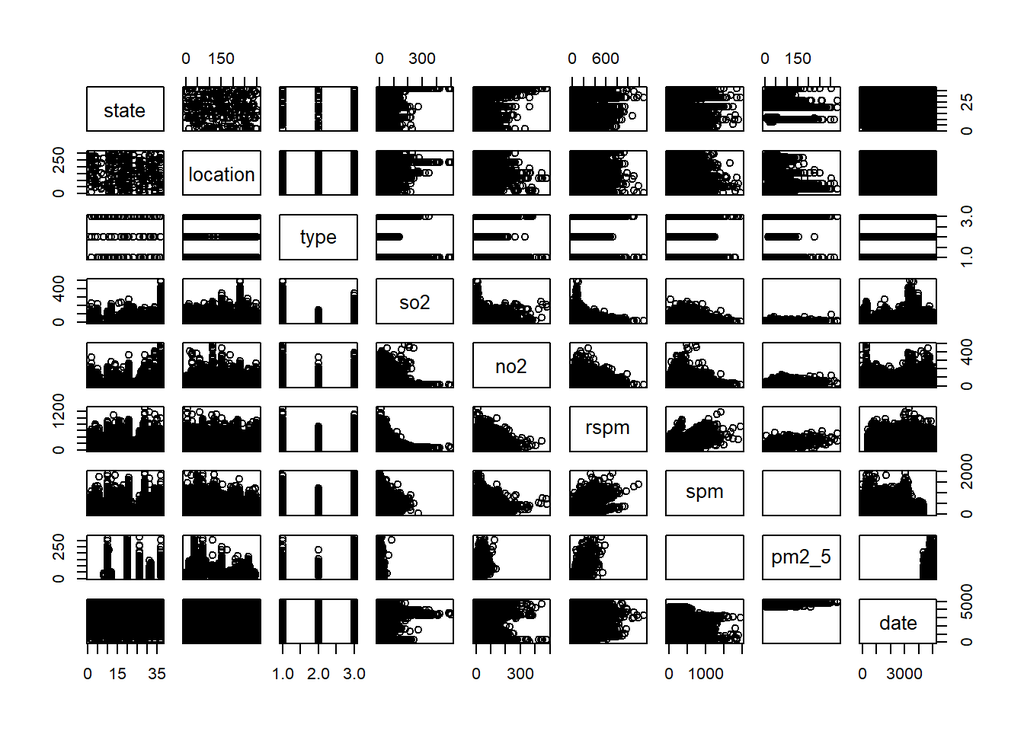

```r
plot(df)
```

### 2. bivarite plot

```r
plotdata <- df_c %>%
  group_by(state) %>%
  summarize(mean_1 = mean(so2))
plotdata
```

```
## # A tibble: 32 x 2
##    state                mean_1
##    <chr>                 <dbl>
##  1 Andhra Pradesh         6.88
##  2 Assam                  6.71
##  3 Bihar                  9.83
##  4 Chandigarh             3.50
##  5 Chhattisgarh          15.1
##  6 Dadra & Nagar Haveli   9.55
##  7 Daman & Diu            9.27
##  8 Delhi                  8.04
##  9 Goa                    7.58
## 10 Gujarat               15.7
## # ... with 22 more rows
```

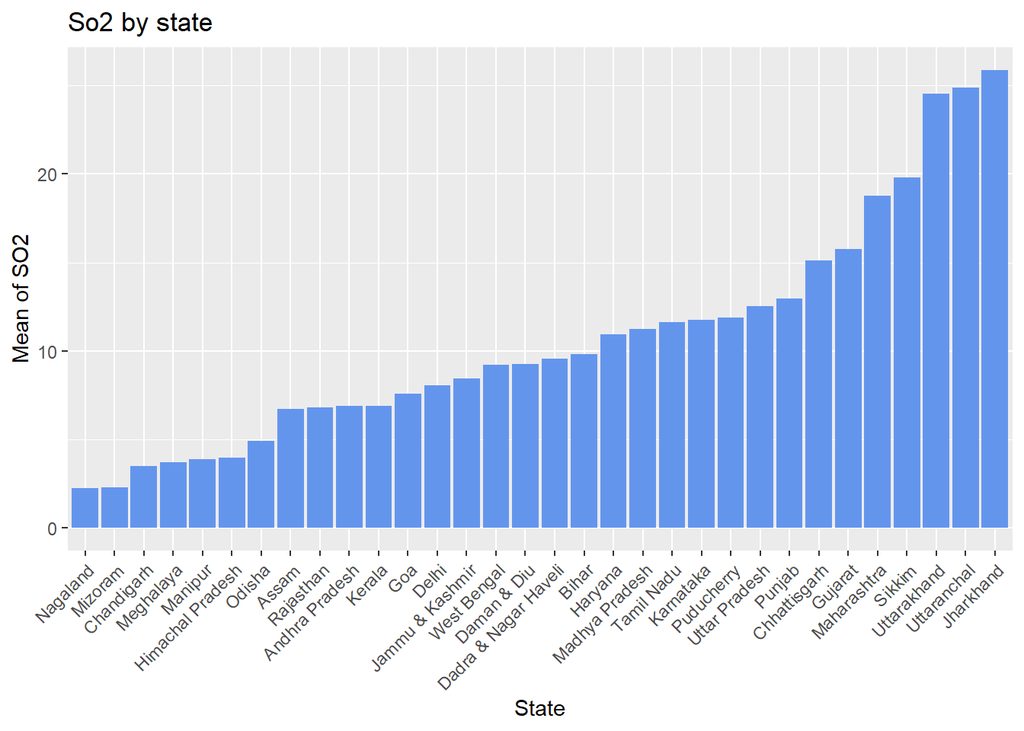

```r
ggplot(plotdata, aes(x = reorder(state, mean_1), y = mean_1)) +
  geom_bar(stat = "identity", fill = "cornflowerblue") +
  theme(axis.text.x = element_text(angle = 45, hjust = 1))+
  labs(title = "So2 by state", y = "Mean of SO2", x ="State")
```

#### so2 with type

```r
plotdata <- df_c %>%
  group_by(type) %>%
  summarize(mean_1 = mean(so2))
plotdata
```

```
## # A tibble: 3 x 2
##   type        mean_1
##   <chr>        <dbl>
## 1 Industrial   13.6
## 2 Others        7.12
## 3 Residential  10.0
```

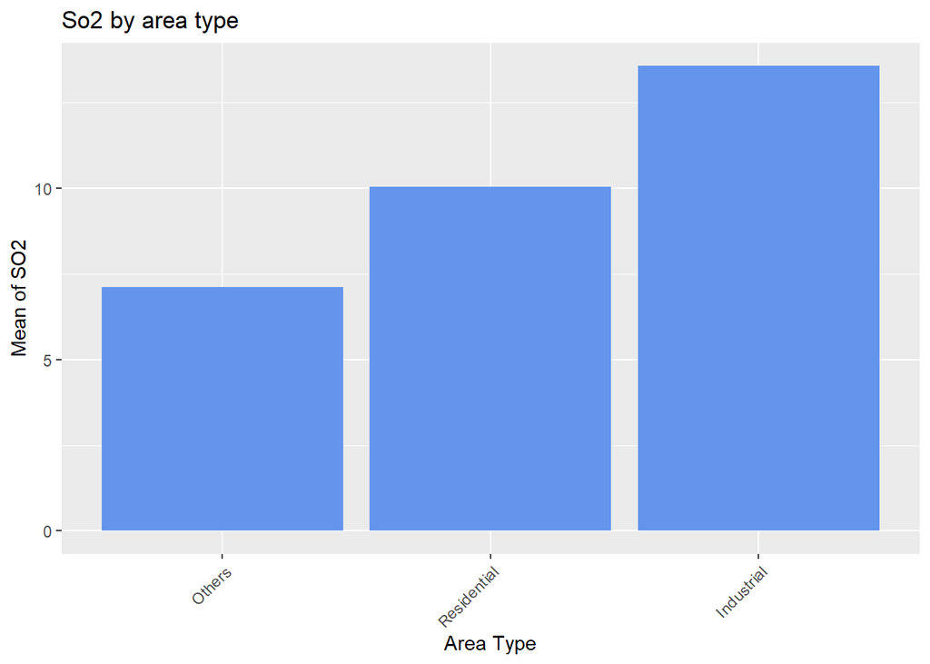

```r
ggplot(plotdata, aes(x = reorder(type, mean_1), y = mean_1)) +
  geom_bar(stat = "identity", fill = "cornflowerblue") +
  theme(axis.text.x = element_text(angle = 45, hjust = 1))+
  labs(title = "So2 by area type", y = "Mean of SO2", x ="Area Type")
```

#### no2 with state

```r
plotdata <- df_c %>%
  group_by(state) %>%
  summarize(mean_1 = mean(no2))
plotdata
```

```
## # A tibble: 32 x 2
##    state                mean_1
##    <chr>                 <dbl>
##  1 Andhra Pradesh         26.0
##  2 Assam                  14.9
##  3 Bihar                  35.1
##  4 Chandigarh             20.5
##  5 Chhattisgarh           26.7
##  6 Dadra & Nagar Haveli   17.5
##  7 Daman & Diu            17.6
##  8 Delhi                  50.5
##  9 Goa                    13.0
## 10 Gujarat                24.3
## # ... with 22 more rows
```

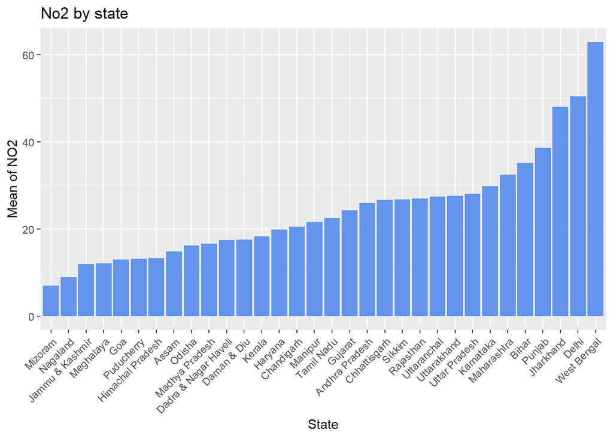

```r
ggplot(plotdata, aes(x = reorder(state, mean_1), y = mean_1)) +
  geom_bar(stat = "identity", fill = "cornflowerblue") +
  theme(axis.text.x = element_text(angle = 45, hjust = 1))+
  labs(title = "No2 by state", y = "Mean of NO2", x ="State")
```

#### no2 with type

```r
plotdata <- df_c %>%
  group_by(type) %>%
  summarize(mean_1 = mean(no2))
plotdata
```

```
## # A tibble: 3 x 2
##   type        mean_1
##   <chr>        <dbl>
## 1 Industrial    32.0
## 2 Others        22.0
## 3 Residential   26.4
```

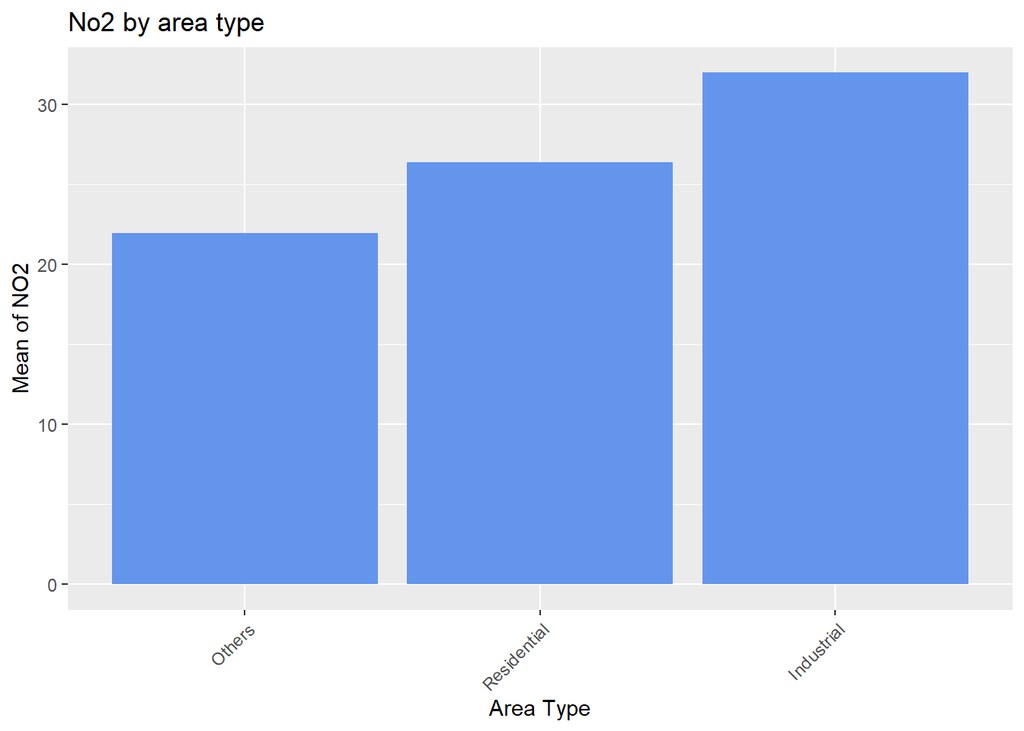

```r
ggplot(plotdata, aes(x = reorder(type, mean_1), y = mean_1)) +
  geom_bar(stat = "identity", fill = "cornflowerblue") +
  theme(axis.text.x = element_text(angle = 45, hjust = 1))+
  labs(title = "No2 by area type", y = "Mean of NO2", x ="Area Type")
```

#### rspm with state

```r
plotdata <- df_c %>%
  group_by(state) %>%
  summarize(mean_1 = mean(rspm))
plotdata
```

```
## # A tibble: 32 x 2
##    state                mean_1
##    <chr>                 <dbl>
##  1 Andhra Pradesh         83.5
##  2 Assam                  92.9
##  3 Bihar                 104.
##  4 Chandigarh            103.
##  5 Chhattisgarh          131.
##  6 Dadra & Nagar Haveli   86.4
##  7 Daman & Diu            84.7
##  8 Delhi                 186.
##  9 Goa                    68.9
## 10 Gujarat               104.
## # ... with 22 more rows
```

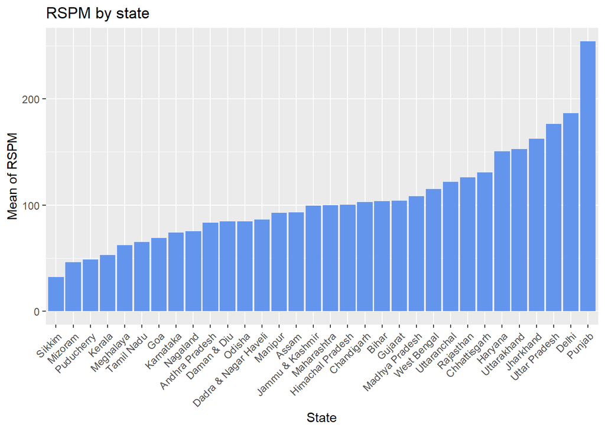

```r
ggplot(plotdata, aes(x = reorder(state, mean_1), y = mean_1)) +
  geom_bar(stat = "identity", fill = "cornflowerblue") +
  theme(axis.text.x = element_text(angle = 45, hjust = 1))+
  labs(title = "RSPM by state", y = "Mean of RSPM", x ="State")
```

#### rspm with type

```r
plotdata <- df_c %>%
  group_by(type) %>%
  summarize(mean_1 = mean(rspm))
plotdata
```

```
## # A tibble: 3 x 2
##   type        mean_1
##   <chr>        <dbl>
## 1 Industrial    121.
## 2 Others        101.
## 3 Residential   103.
```

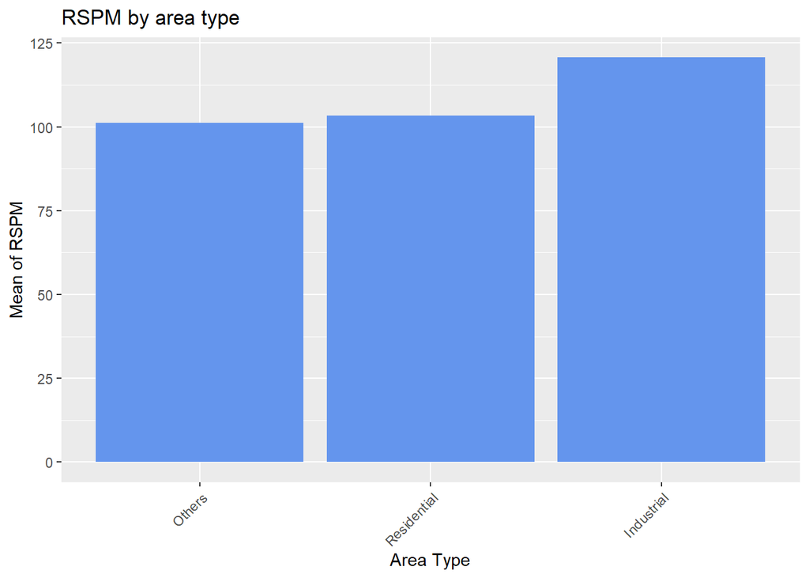

```r
ggplot(plotdata, aes(x = reorder(type, mean_1), y = mean_1)) +
  geom_bar(stat = "identity", fill = "cornflowerblue") +
  theme(axis.text.x = element_text(angle = 45, hjust = 1))+
  labs(title = "RSPM by area type", y = "Mean of RSPM", x ="Area Type")
```

#### spm with state

```r
plotdata <- df_c %>%
  group_by(state) %>%
  summarize(mean_1 = mean(spm))
plotdata
```

```
## # A tibble: 32 x 2
##    state                mean_1
##    <chr>                 <dbl>
##  1 Andhra Pradesh        205.
##  2 Assam                 156.
##  3 Bihar                 255.
##  4 Chandigarh            202.
##  5 Chhattisgarh          236.
##  6 Dadra & Nagar Haveli  217.
##  7 Daman & Diu           209.
##  8 Delhi                 418.
##  9 Goa                    44.5
## 10 Gujarat               178.
## # ... with 22 more rows
```

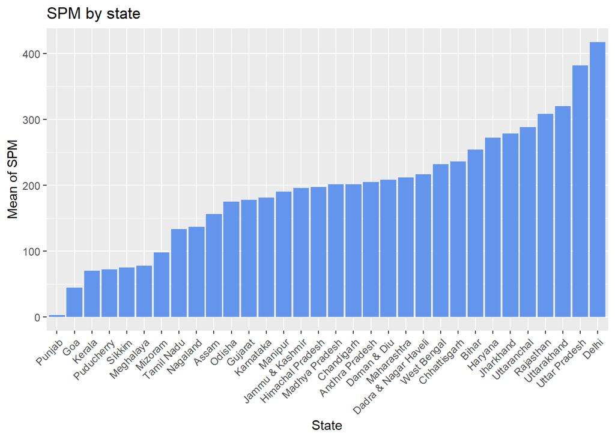

```r
ggplot(plotdata, aes(x = reorder(state, mean_1), y = mean_1)) +
  geom_bar(stat = "identity", fill = "cornflowerblue") +
  theme(axis.text.x = element_text(angle = 45, hjust = 1))+
  labs(title = "SPM by state", y = "Mean of SPM", x ="State")
```

#### spm with type

```r
plotdata <- df_c %>%
  group_by(type) %>%
  summarize(mean_1 = mean(spm))
plotdata
```

```
## # A tibble: 3 x 2
##   type        mean_1
##   <chr>        <dbl>
## 1 Industrial    245.
## 2 Others        221.
## 3 Residential   213.
```

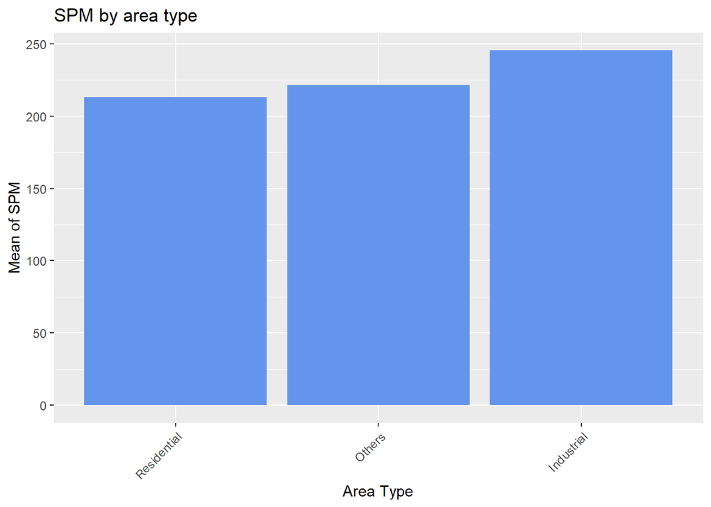

```r
ggplot(plotdata, aes(x = reorder(type, mean_1), y = mean_1)) +
  geom_bar(stat = "identity", fill = "cornflowerblue") +
  theme(axis.text.x = element_text(angle = 45, hjust = 1))+
  labs(title = "SPM by area type", y = "Mean of SPM", x ="Area Type")
```